# Identifying Fraud from Enron Financial and Email Data Set

## Introduction

Enron was one of the major American energy companies based originally in Houston, Texas in which by 2002, had completely collapsed into bankruptcy as a result of audit failure and corporate fraud. In this study, we will attempt to build a person of interest identifier based on the Enron dataset which is a dictionary combined from the Enron financial and email data where there exists one to one correspondence between each person and a key value pair in the dictionary.

## Analysis

First, we are trying to see a plot showing salary versus bonus distribution in which the following code produces below. We manually selected these features because bonus and salary may be features that may be correlated with analyzing POIs.

```
146
94
```

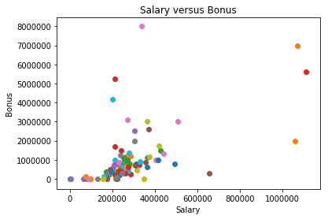

```python
import matplotlib.pyplot as plt
import sys
import pickle
from sklearn import preprocessing
from time import time
from sklearn.naive_bayes import GaussianNB
from sklearn.metrics import accuracy_score
from sklearn.metrics import precision_score
from sklearn.metrics import recall_score
from sklearn.grid_search import GridSearchCV
sys.path.append("../tools/")


from feature_format import featureFormat
from feature_format import targetFeatureSplit


## We are loading the dictionary that contains the dataset
data_dict = pickle.load(open("final_project_dataset.pkl", "r") )

## We are counting the number of exeutives in our data.
print len(data_dict.keys())

## Here we are removing the outliers
features = ["salary", "bonus"]
data_dict.pop('TOTAL', 0)
data = featureFormat(data_dict, features)

## Here we are removing NAN's from our dataset
outliers = []
for key in data_dict:
   val = data_dict[key]['salary']
   if val == 'NaN':
        continue
   outliers.append((key, int(val)))

outliers_final = (sorted(outliers,key=lambda x:x[1],reverse=True)[:4])


## Now we are ready to plot the features:
for point in data:
   salary = point[0]
   bonus = point[1]
   plt.scatter( salary, bonus )

plt.title("Salary versus Bonus")
plt.xlabel("Salary")
plt.ylabel("Bonus")

t=0
for point in data:
   t=t+1
print t
```

There are 146 executives and a total of 94 data points in our plot of salary versus bonus.

In the following codes below, we will remove the primary outliers. Since there are not many POIs, it is not necessary to remove the other outliers apart from the primary ones because removing the other outliers may further imbalance the dataset.

```python
##The below code corresponds to outliers in terms of salary figure per year.

outliers_final
```

```
[('SKILLING JEFFREY K', 1111258),
 ('LAY KENNETH L', 1072321),
 ('FREVERT MARK A', 1060932),
 ('PICKERING MARK R', 655037)]
```

The below code corresponds to the outliers in terms of bonus figure per year.

```python
data_dict = pickle.load(open("final_project_dataset.pkl", "r") )
```

```python
## We're removing outliers below
features = ["salary", "bonus"]
data_dict.pop('TOTAL', 0)
data = featureFormat(data_dict, features)

## Now we are removing the NAN's from dataset
outliers2 = []
for key in data_dict:
   val = data_dict[key]['bonus']
   if val == 'NaN':
       continue
   outliers2.append((key, int(val)))

outliers_final2 = (sorted(outliers2,key=lambda x:x[1],reverse=True)[:4])
```

```python
outliers_final2
```

```
[('LAVORATO JOHN J', 8000000),
 ('LAY KENNETH L', 7000000),
 ('SKILLING JEFFREY K', 5600000),
 ('BELDEN TIMOTHY N', 5249999)]
```

```python
print data_dict['BELDEN TIMOTHY N']
print data_dict['LAVORATO JOHN J']
```

```
{'salary': 213999, 'to_messages': 7991, 'deferral_payments': 2144013, 'total_payments': 5501630, 'exercised_stock_options': 953136, 'bonus': 5249999, 'restricted_stock': 157569, 'shared_receipt_with_poi': 5521, 'restricted_stock_deferred': 'NaN', 'total_stock_value': 1110705, 'expenses': 17355, 'loa…
{'salary': 339288, 'to_messages': 7259, 'deferral_payments': 'NaN', 'total_payments': 10425757, 'exercised_stock_options': 4158995, 'bonus': 8000000, 'restricted_stock': 1008149, 'shared_receipt_with_poi': 3962, 'restricted_stock_deferred': 'NaN', 'total_stock_value': 5167144, 'expenses': 49537, 'lo…
```

Assuming that money played an incentive to commit fraud, we were trying to see if we can find outliers in people who received unusually high bonusus and salary. We found that the scatterplot generated 4 outliers in terms of both salary and bonuses. The outliers for very salary were found to be Skilling Jeffrey K, Lay Kenneth L, Frevert Mark A, and Pickering Mark R. The outliers for unusually high bonuses were found to be Lavorato John J, Lay Kenneth L, Skilling Jeffrey K, and Belden Timothy N. We see that Skilling Jeffrey K and Lay Kenneth L earned both high salary and bonuses. However, high salary outlier did not necessarily mean the same names resulted in high outlier for bonuses. For example, Lavorato John J and Belden Timothy N received unusually high bonuses but did not turn out to be outlier salary earners.

Since salary income is fixed, let us focus more on the bonus outliers. We expect that people with high salaries would correspond to higher bonuses. However, Lovorato John J earned an unusually high 8,000,000 bonus but his salaray is not in the outlier range which was 339,288. Also, Belden Timothy N earned 5,249,999 while his salary was no where near the highest salary range in our data of 213,999. Skilling Jeffrey K and Lay Kenneth L turned out to be people who earned both high salaries and bonuses.

Below we ran a regression on salary versus bonus. We found that our R^2 0.32 which is not a good model for the data. The data is mainly clustered close to the regression line in the bottom left hand quarter of the plot below. However, the as salary and bonus increase, the data gets more spread out.

```
('Coefficients: \n', array([[ 4.44516239]]))
Mean squared error: 1327632798051.18
Variance score: 0.32
```

```
Text(0,0.5,u'Bonus')
```

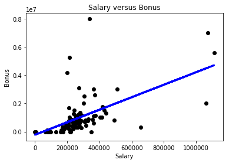

```python
%matplotlib inline
import matplotlib.pyplot as plt
import numpy as np
from sklearn import datasets, linear_model
from sklearn.metrics import mean_squared_error, r2_score

## Create linear regression object
regr = linear_model.LinearRegression()

## X is our salary data
X=(data[:,0])

## Y is our bonus data
Y=(data[:,1])

## Train the model using the training sets
regr.fit(X[:, np.newaxis], Y[:, np.newaxis])

## Make predictions using the testing set
Y_pred = regr.predict(X[:, np.newaxis])

## The Coefficients
print('Coefficients: \n', regr.coef_)

## The Mean Squared Error
print("Mean squared error: %.2f"
      % mean_squared_error(Y, Y_pred))
## Explained variance score: 1 is perfect prediction
print('Variance score: %.2f' % r2_score(Y, Y_pred))

## Now we are plotting the outputs:
plt.scatter(X, Y,  color='black')
plt.plot(X, Y_pred, color='blue', linewidth=3)

plt.title("Salary versus Bonus")
plt.xlabel("Salary")
plt.ylabel("Bonus")
```

We tried to remove our bonus and salary outliers in our linear regression below.

```python
def removekey(d, key):
   r = dict(d)
   del r[key]
   return r
```

```python
## Create salary data set and remove the six outliers, same guys from both salary and bonus
outliers_salary = removekey(outliers,outliers_final[0][0])
outliers_salary = removekey(outliers_salary,outliers_final[1][0])
outliers_salary = removekey(outliers_salary,outliers_final[2][0])
outliers_salary = removekey(outliers_salary,outliers_final[3][0])

## We are now removing the salary outliers:
outliers_salary = removekey(outliers_salary,outliers_final2[0][0])
outliers_salary = removekey(outliers_salary,outliers_final2[3][0])

## We are now creating the bonus data set and removing the six outliers, same guys from both salary and bonus
outliers_bonus = removekey(outliers2,outliers_final[0][0])
outliers_bonus = removekey(outliers_bonus,outliers_final[1][0])
outliers_bonus = removekey(outliers_bonus,outliers_final[2][0])
outliers_bonus = removekey(outliers_bonus,outliers_final[3][0])

## We are now removing the bonus outliers
outliers_bonus = removekey(outliers_bonus,outliers_final2[0][0])
outliers_bonus = removekey(outliers_bonus,outliers_final2[3][0])
```

```
('Coefficients: \n', array([[-0.73849292]]))
Mean squared error: 573737964088.74
Variance score: 0.01
```

```
Text(0,0.5,u'Bonus')
```

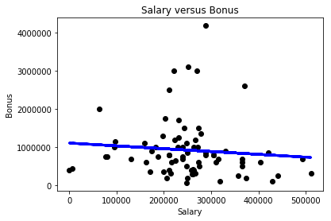

```python
%matplotlib inline
import matplotlib.pyplot as plt
import numpy as np
from sklearn import datasets, linear_model
from sklearn.metrics import mean_squared_error, r2_score

## Create linear regression object
regr = linear_model.LinearRegression()

## X is our salary data
X=np.array(outliers_salary.values())
X=X[:-13]

## Y is our bonus data
Y=np.array(outliers_bonus.values())

## We're now training the model using the training sets
regr.fit(X[:, np.newaxis], Y[:, np.newaxis])

## Make predictions using the testing set
Y_pred = regr.predict(X[:, np.newaxis])

## The Coefficients
print('Coefficients: \n', regr.coef_)

## The mean squared error
print("Mean squared error: %.2f"
      % mean_squared_error(Y, Y_pred))

## Variance score
print('Variance score: %.2f' % r2_score(Y, Y_pred))

## Plot the outputs
plt.scatter(X, Y,  color='black')
plt.plot(X, Y_pred, color='blue', linewidth=3)

plt.title("Salary versus Bonus")
plt.xlabel("Salary")
plt.ylabel("Bonus")
```

We removed our outliers for bonus and salary in the plot above. However, we discovered that R^2 actually became worse when we removed our outliers. Therefore, we see that linear regression is not a good model for analyzing our data.

Because our linear regression between bonus and salary was not a good model for our data, we are now running a PCA plot for Salary and Bonus. 0.98928806 and 0.01071194 are our eigenvalues that were printed out from our PCA plot. The red in the plot is the direction of the first principal component and the cyane is the direction of the second principal component. We see that the red line is a better fit to our data.

```
[ 0.98928806  0.01071194]
```

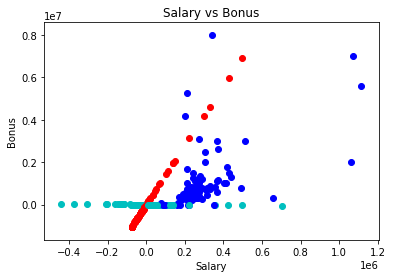

```python
import matplotlib

def doPCA():
    from sklearn.decomposition import PCA
    pca = PCA(n_components=2)
    pca.fit(data)
    return pca

pca = doPCA()
print pca.explained_variance_ratio_
first_pc = pca.components_[0]
second_pc = pca.components_[1]

transformed_data = pca.transform(data)


for ii, jj in zip(transformed_data,data):
    plt.scatter( first_pc[0]*ii[0], first_pc[1]*ii[0], color="r")
    plt.scatter( second_pc[0]*ii[1], second_pc[1]*ii[1], color="c")
    plt.scatter( jj[0], jj[1], color="b")

plt.xlabel("Salary")
plt.ylabel("Bonus")
plt.title("Salary vs Bonus")

xfmt = matplotlib.ticker.ScalarFormatter()
xfmt.set_powerlimits((-3,3))
matplotlib.pyplot.gca().xaxis.set_major_formatter(xfmt)
```

We got our poi data from the training set which includes features as well as correct answers. Below, the people who the result came out to be true are our POIs and in our case, there are 3 people of POI.

```python
data_dict["SKILLING JEFFREY K"]["poi"]
```

```
True
```

```python
data_dict["LAVORATO JOHN J"]["poi"]
```

```
False
```

```python
data_dict["LAY KENNETH L"]["poi"]
```

```
True
```

```python
 data_dict["BELDEN TIMOTHY N"]["poi"]
```

```
True
```

```python
data_dict["FREVERT MARK A"]["poi"]
```

```
False
```

```python
data_dict["PICKERING MARK R"]["poi"]
```

```
False
```

```python
### remove any outliers before proceeding further
features = ["salary", "bonus"]
data_dict.pop('TOTAL', 0)
data = featureFormat(data_dict, features)

### remove NAN's from dataset
outliers = []
for key in data_dict:
    val = data_dict[key]['salary']
    if val == 'NaN':
        continue
    outliers.append((key, int(val)))

outliers_final = (sorted(outliers,key=lambda x:x[1],reverse=True)[:4])
### print top 4 salaries
print outliers_final
```

```
[('SKILLING JEFFREY K', 1111258), ('LAY KENNETH L', 1072321), ('FREVERT MARK A', 1060932), ('PICKERING MARK R', 655037)]
```

```python
## NaN is missing value in this case. We're counting the T to findout the missing values.
T=0

outliers = []
for key in data_dict:
   val = data_dict[key]['salary']
   if val == 'NaN':
        T=T+1
        continue
   outliers.append((key, int(val)))

outliers_final = (sorted(outliers,key=lambda x:x[1],reverse=True)[:4])
print T
```

```
51
```

```python
T=0

outliers = []
for key in data_dict:
   val = data_dict[key]['bonus']
   if val == 'NaN':
        T=T+1
        continue
   outliers.append((key, int(val)))

outliers_final = (sorted(outliers,key=lambda x:x[1],reverse=True)[:4])
print T
```

```
64
```

We have 51 missing values for salary feature and there are 64 missing values for the bonus feature.

The two new features that are being created are normalized_email_from_poi and normalized_email-to_poi. Because our linear regression was not a good model, we will include the outliers in our analysis for the two new features we are analyzing below. Normalized_email_from_poi and normalized_email-to_poi means that we are looking at normalized existing features from the dataset. We chose to focus on these features because conceptually, it makes sense to try to analyze the portion of communications that were going on via emails between a poi and another person. Because there was no strong pattern between already existing features ('from_poi_to_this_person' and 'from_this_person_to_poi'), in the following code we engineered new features by modifying them through normalization.

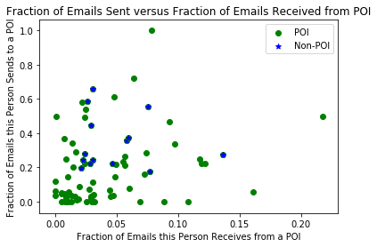

```python
## New chosen features are: normalized_email_to_poi,normalized_email_from_poi

def dict_to_list(key,normalizer):
    new_list=[]

    for i in data_dict:
        if data_dict[i][key]=="NaN" or data_dict[i][normalizer]=="NaN":
            new_list.append(0.)
        elif data_dict[i][key]>=0:
            new_list.append(float(data_dict[i][key])/float(data_dict[i][normalizer]))
    return new_list

## We are now creating two lists of new features:
normalized_email_from_poi=dict_to_list("from_poi_to_this_person","to_messages")
normalized_email_to_poi=dict_to_list("from_this_person_to_poi","from_messages")

## We are now putting new features into the data_dict
count=0
for i in data_dict:
    data_dict[i]["normalized_email_from_poi"]=normalized_email_from_poi[count]
    data_dict[i]["normalized_email_to_poi"]=normalized_email_to_poi[count]
    count +=1


features_list = ["poi", "normalized_email_from_poi", "normalized_email_to_poi"]

my_dataset = data_dict
data = featureFormat(my_dataset, features_list)

## Now we can plot our new features:

for point in data:
    from_poi = point[1]
    to_poi = point[2]
    x=plt.scatter( from_poi, to_poi, color='green')
    if point[0] == 1:
        y=plt.scatter(from_poi, to_poi, color="blue", marker="*")

plt.legend((x,y),("POI","Non-POI"))



plt.xlabel("Fraction of Emails this Person Receives from a POI")
plt.ylabel("Fraction of Emails this Person Sends to a POI")
plt.title("Fraction of Emails Sent versus Fraction of Emails Received from POI")
plt.show()
```

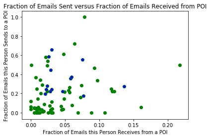

```
POI:  14
non-POI 77
```

```python
## Checking and printing to see how many POIs and Non-POIs there are

number_of_poi = 0
number_of_nonpoi = 0
for point in data:
  from_poi = point[1]
  to_poi = point[2]
  x=plt.scatter( from_poi, to_poi, color='green')
  number_of_nonpoi = number_of_nonpoi+1
  if point[0] == 1:
      y=plt.scatter(from_poi, to_poi, color="blue", marker="*")
      number_of_poi = number_of_poi+1


plt.xlabel("Fraction of Emails this Person Receives from a POI")
plt.ylabel("Fraction of Emails this Person Sends to a POI")
plt.title("Fraction of Emails Sent versus Fraction of Emails Received from POI")
plt.show()

print "POI: ", number_of_poi
print "non-POI", number_of_nonpoi
```

Because our scatter plot analyzing the normalized emails sent versus normalized emails received from POIs did not show any clear pattern, in our next step we will be applying decision tree algorithm to rank the features. We are not going to use feature scaling in this case because it’s not necessary for using a decision tree.

We are using decision tree classifier to score all possible features according to their ability to match the target function. The features were selected using a semi-automated method-- (introducing human intuition into the feature selection). Semi-automated method in this case means selecting the normalized_email_from_poi and normalized_email_to_poi features which were 3rd and 4th rankings that resulted from the decision tree below.

```python
##Decision Tree Application

import numpy as np
import pandas as pd
from sklearn.cross_validation import train_test_split
from sklearn.tree import DecisionTreeClassifier
from sklearn.metrics import accuracy_score
from sklearn import tree


features_list = ["poi","bonus", "salary","normalized_email_from_poi","normalized_email_to_poi",
                 'loan_advances','deferral_payments',
                 'deferred_income', 'total_stock_value', 'exercised_stock_options',
                'restricted_stock_deferred','expenses','long_term_incentive','total_payments', 'shared_receipt_with_poi', 'restricted_stock', 'director_fees']

## The below code is to see how many features we have in total from above:
print len(features_list)


data = featureFormat(my_dataset, features_list)

labels, features = targetFeatureSplit(data)

#We are now splitting the data into training versus testing data
from sklearn import cross_validation
features_training, features_testing, labels_training, labels_testing = cross_validation.train_test_split(features, labels, test_size=0.3, random_state=42)



clf = DecisionTreeClassifier(min_samples_split=7)
clf.fit(features_training,labels_training)
score = clf.score(features_testing,labels_testing)
pred= clf.predict(features_testing)
print 'accuracy', score



importances = clf.feature_importances_
import numpy as np
indices = np.argsort(importances)[::-1]
print 'Feature Ranking: '
for i in range(16):
    print "{} feature {} ({})".format(i+1,features_list[i+1],importances[indices[i]])
```

```
17
accuracy 0.818181818182
Feature Ranking:
1 feature bonus (0.25)
2 feature salary (0.247058823529)
3 feature normalized_email_from_poi (0.204318689501)
4 feature normalized_email_to_poi (0.176470588235)
5 feature loan_advances (0.0633283693224)
6 feature deferral_payments (0.0588235294118)
7 feature deferred_income (0.0)
8 feature total_stock_value (0.0)
9 feature exercised_stock_options (0.0)
10 feature restricted_stock_deferred (0.0)
11 feature expenses (0.0)
12 feature long_term_incentive (0.0)
13 feature total_payments (0.0)
14 feature shared_receipt_with_poi (0.0)
15 feature restricted_stock (0.0)
16 feature director_fees (0.0)
```

## Fine Tuning

Models are parameterized in machine learning and their behaviors can be tuned. In the context of machine learning, this means that since models may have many parameters, we must look for ways or attempt to find the best combination of features and parameters so that our chosen model can optimally solve the machine learning problem we are trying to study.

In the context of machine learning, parameter tuning's end goal is to find the best hyper-parameters. Hyperparameters are usually fixed before the training process and are pre-defined parameters of the model, such as the K of K-means. Learned parameters on the other hand, are the parameters learned automaticlly in the model training process such as the coefficient results genearted from linear regressions.

Thus, in order to find the best hyperparameters, it is important to experiment and set different values for the hyperparameters, train different models, and then decide which ones work best by testing them. Parameter tuning plays a significant role in machine learning because if the hyper-parameters are not set up correctly, a very good algorithm may still output bad results.

For example, we already saw in our code above, that the decision tree application did not yield very good results. The issue may be that it isn't the algorithm that is causing the bad results but that we need to adjust our features and parameters. This is why we're going to try fine tuning now by experimenting with selecting a different combination of features and observe if that would give us better accuracy. We are also going to experiment setting our parameter of min_sample_split to different values to see which value generates better precision.

In the codes that will come below, we will be applying the Naive Bayes algorithm and Decision Tree algorithm for different sets of features and compare them.

```python
##Checking to see if the numbers for bonus +salary does indeed = total_payments
#Here, we're just checking for Skilling, Jeffrey.

data_dict['SKILLING JEFFREY K']["salary"]+data_dict['SKILLING JEFFREY K']["bonus"]
```

```
6711258
```

```python
#Now we're selecting the following features: poi, normalized_email_from_poi, normalized_email_to_poi, and total_payments.

features_list = ["poi","normalized_email_from_poi","normalized_email_to_poi",'total_payments']

t0 = time()

clf = GaussianNB()
clf.fit(features_training, labels_training)
pred = clf.predict(features_testing)
accuracy = accuracy_score(pred,labels_testing)
print accuracy
```

```
0.295454545455
```

Now we are going to experiment with fine tuning our data by changing our parameter, --that is the min sample split.

```python
## Define the list of features according to our previous selection and making a copy of the data dictionary
features_list = ["poi","normalized_email_from_poi","normalized_email_to_poi",'total_payments']

my_dataset = data_dict

data = featureFormat(my_dataset, features_list)

##Splitting the data into POI and features
labels, features = targetFeatureSplit(data)


from sklearn import cross_validation
features_training, features_testing, labels_training, labels_testing = cross_validation.train_test_split(features, labels, test_size=0.3, random_state=42)

## Now we want to use K-fold for validation
from sklearn.cross_validation import KFold
kf=KFold(len(labels),3)
for train_indices, test_indices in kf:


    features_train= [features[ii] for ii in train_indices]
    features_test= [features[ii] for ii in test_indices]
    labels_train=[labels[ii] for ii in train_indices]
    labels_test=[labels[ii] for ii in test_indices]

from sklearn.tree import DecisionTreeClassifier

t0 = time()

clf = DecisionTreeClassifier(min_samples_split=2)
clf.fit(features_training,labels_training)
pred= clf.predict(features_testing)
score = clf.score(features_testing,labels_testing)
print 'accuracy before tuning ', score

print "Decision tree algorithm time:", round(time()-t0, 3), "s"


## Now we are using manual tuning parameter for the min_samples_split=4
t0 = time()
clf = DecisionTreeClassifier(min_samples_split=4)
clf = clf.fit(features_training,labels_training)
pred= clf.predict(features_testing)
print("done in %0.3fs" % (time() - t0))

acc=accuracy_score(labels_testing, pred)

print "Validating algorithm:"
print "accuracy after tuning = ", acc

## Calculating the ratio of true positives from all positives

print 'precision = ', precision_score(labels_testing,pred)

## Calculating ratio of true positives out of true positives and false negatives

print 'recall = ', recall_score(labels_testing,pred)


pickle.dump(clf, open("my_classifier.pkl", "w") )
pickle.dump(data_dict, open("my_dataset.pkl", "w") )
pickle.dump(features_list, open("my_feature_list.pkl", "w") )
```

```
accuracy before tuning  0.825
Decision tree algorithm time: 0.003 s
done in 0.002s
Validating algorithm:
accuracy after tuning =  0.8
precision =  0.25
recall =  0.166666666667
```

There seems to be a small amount of run to run variability in precision. I believe this is happening due to overfitting when min sample size = 2.

min_samples_split Accuracy 2 0.825 3 0.825 4 0.8 5 0.8 6 0.825 7 0.85 8 0.825

```python
Average= [0.825,0.825,0.8,0.8,0.825,0.85,0.825]
import numpy as np
print np.mean(Average)
```

```
0.821428571429
```

```python
#Here we are calculating the F Beta Score

from sklearn.metrics import fbeta_score
y_true = labels_testing
y_pred = pred
fbeta_score(y_true, y_pred, average='macro', beta=0.5)
```

```
0.54902962206332995
```

Because our accuracy results were not very good when using the feature above ("poi","normalized_email_from_poi","normalized_email_to_poi", and 'total_payments'), we are going to experiment with a different set of features to see if that would yield better results.

Now, the following codes will run the Naive Bayes and the Decision Tree algorithm for "POI", normalized_email_from_poi","normalized_email_to_poi", and 'shared_receipts_with_poi'.

```python
#Now we're selecting the following features: poi, normalized_email_from_poi, normalized_email_to_poi, and shared_receipt_with_poi.

features_list = ["poi","normalized_email_from_poi","normalized_email_to_poi",'shared_receipt_with_poi']

t0 = time()

clf = GaussianNB()
clf.fit(features_training, labels_training)
pred = clf.predict(features_testing)
accuracy = accuracy_score(pred,labels_testing)
print accuracy
```

```
0.85
```

We saw previously that using "poi","normalized_email_from_poi","normalized_email_to_poi", and 'total_payments' features we selected did not give us a precision better than 0.3. Therefore, we already said we would try the poi feature, our engineered features of "normalized_email_from_poi"and "normalized_email_to_poi", but change the last feature to shared_receipts_with poi to see if we can generate better results.

So in the code below, we're going to see if we can yield better results using the shared_receipts instead of total payments in our decision tree algorithm.

```python
## Define the list of features according to our previous selection and making a copy of the data dictionary
features_list = ["poi","normalized_email_from_poi","normalized_email_to_poi",'shared_receipt_with_poi']

my_dataset = data_dict

data = featureFormat(my_dataset, features_list)

##Splitting the data into POI and features
labels, features = targetFeatureSplit(data)


from sklearn import cross_validation
features_training, features_testing, labels_training, labels_testing = cross_validation.train_test_split(features, labels, test_size=0.3, random_state=42)

## Now we want to use K-fold for validation
from sklearn.cross_validation import KFold
kf=KFold(len(labels),3)
for train_indices, test_indices in kf:


    features_train= [features[ii] for ii in train_indices]
    features_test= [features[ii] for ii in test_indices]
    labels_train=[labels[ii] for ii in train_indices]
    labels_test=[labels[ii] for ii in test_indices]

from sklearn.tree import DecisionTreeClassifier

t0 = time()

clf = DecisionTreeClassifier(min_samples_split=2)
clf.fit(features_training,labels_training)
pred= clf.predict(features_testing)
score = clf.score(features_testing,labels_testing)
print 'accuracy before tuning ', score

print "Decision tree algorithm time:", round(time()-t0, 3), "s"


## Now we are using manual tuning parameter for the min_samples_split=4
t0 = time()
clf = DecisionTreeClassifier(min_samples_split=7)
clf = clf.fit(features_training,labels_training)
pred= clf.predict(features_testing)
print("done in %0.3fs" % (time() - t0))

acc=accuracy_score(labels_testing, pred)

print "Validating algorithm:"
print "accuracy after tuning = ", acc

## Calculating the ratio of true positives from all positives

print 'precision = ', precision_score(labels_testing,pred)

## Calculating ratio of true positives out of true positives and false negatives

print 'recall = ', recall_score(labels_testing,pred)


pickle.dump(clf, open("my_classifier.pkl", "w") )
pickle.dump(data_dict, open("my_dataset.pkl", "w") )
pickle.dump(features_list, open("my_feature_list.pkl", "w") )
```

```
accuracy before tuning  0.884615384615
Decision tree algorithm time: 0.002 s
done in 0.002s
Validating algorithm:
accuracy after tuning =  0.884615384615
precision =  0.666666666667
recall =  0.5
```

min_samples_split Accuracy Precision Recall 3 0.884615384615 0.67 0.5 4 0.884615384615 0.67 0.5 5 0.884615384615 0.67 0.5 6 0.884615384615 0.67 0.5 7 0.884615384615 0.67 0.5 8 0.884615384615 0.67 0.5 Average 0.8846 0.67 0.5

The code above replacing the last feature with shared_receipt_with_poi is much more stable from run to run than the original code we had with features= ["poi","normalized_email_from_poi","normalized_email_to_poi",'total_payments'].

We see that accuacy before tuning and after tuning did not change (0.884615384615). Now, our precision is approximately 0.67 and recall is 0.5.

```python
#Here we are calculating the F Beta Score

from sklearn.metrics import fbeta_score
y_true = labels_testing
y_pred = pred
fbeta_score(y_true, y_pred, average='macro', beta=0.5)
```

```
0.77302631578947367
```

## Validation

Because there is a need to test the stability of machine learning model, validation is important step in this project. Validation is the process of deciding whether the numerical results quantifying hypothesized relationships between variables are acceptable as descriptions of the data with low bias and variance. Validation is important because it can test the general power of the model on the unseen dataset. However, validation does not necessarily give a good indication of how well the model will generalize to an independent and unseen data set, but only gives an idea about how well the selected model does on the data used to train it. Therefore, a common problem/mistake with validation is under or overfitting of the data.

In addition, because of the imbalanced issue with this particular dataset regarding the portion of POIs versus non-POIs, we tried using the Stratified ShuffleSplit Cross-validator. The Stratified ShuffleSplit method provides us with the training/testing indices to split data in training/testing sets.

We also chose this method because this cross-validation object is a merge of StratifiedKFold and ShuffleSplit, returning stratified randomized folds, and these folds are generated by preserving the percentage of samples for each class. In ShuffleSplit, the data is shuffled every time, and then split, letting the testing sets overlap between the splits.

```python
#!/usr/bin/python
# Note that this file must be run from within anaconda to insure that all the libraries are found.
# Note that all personal workspaces have been removed from these codes and it should run in any directory:
import sys
import pickle
sys.path.append("../tools/")
from feature_format import featureFormat, targetFeatureSplit
from tester import dump_classifier_and_data
from sklearn import preprocessing
from sklearn.cross_validation import train_test_split
from sklearn.feature_selection import SelectKBest
from sklearn.svm import LinearSVC
from sklearn.decomposition import PCA
from sklearn.cross_validation import StratifiedShuffleSplit
from collections import defaultdict
import sklearn.grid_search
import sklearn.pipeline
import math
from sklearn import preprocessing
from sklearn.linear_model import LogisticRegression

### Task 1: Select what features you'll use.
### The first feature must be "poi".
finance_features = ['salary', 'deferral_payments', 'total_payments', 'loan_advances', 'bonus', 'restricted_stock_deferred', 'deferred_income', 'total_stock_value', 'expenses', 'exercised_stock_options', 'other', 'long_term_incentive', 'restricted_stock', 'director_fees']
##all units are in US dollars

### Load the dictionary containing the dataset
with open("final_project_dataset.pkl", "r") as data_file:
    data_dict = pickle.load(data_file)
my_dataset = data_dict

### Task 2: Remove outliers

del my_dataset['TOTAL']

### Task 3: Create new feature(s)


features_list = ["poi","normalized_email_from_poi","normalized_email_to_poi",'shared_receipt_with_poi']



def add_new_features(x):
    """
    Created three ratios based on email : to,from, and shared with POIs
    """
    if(x['from_messages']!='NaN' and x['from_this_person_to_poi']!='NaN'):
        ratio_from_x_to_poi = x['from_this_person_to_poi'] / float(x['from_messages'])
    else:
        ratio_from_x_to_poi = 0.

    if(x['to_messages']!='NaN' or x['from_poi_to_this_person']!='NaN'):
        ratio_from_poi_to_x = x['from_poi_to_this_person'] / float(x['to_messages'])
    else:
        ratio_from_poi_to_x = 0.

    if(x['to_messages']!='NaN' and x['shared_receipt_with_poi']!='NaN'):
        ratio_shared_receipt_with_poi = x['shared_receipt_with_poi'] / float(x['to_messages'])
    else:
        ratio_shared_receipt_with_poi = 0.

    return ratio_from_x_to_poi , ratio_from_poi_to_x , ratio_shared_receipt_with_poi

#Initialize feature with 0.0
for i in my_dataset:
    my_dataset[i]['ratio_to_poi'] = 0.
    my_dataset[i]['ratio_from_poi'] = 0.
    my_dataset[i]['ratio_shared_receipt'] = 0.

#Set value
for i in my_dataset :
    ratio_to_poi , ratio_from_poi , ratio_shared_receipt = add_new_features(my_dataset[i])
    my_dataset[i]['ratio_to_poi'] = ratio_to_poi
    my_dataset[i]['ratio_from_poi'] = ratio_from_poi
    my_dataset[i]['ratio_shared_receipt'] = ratio_shared_receipt

def log_features(x):

    d = defaultdict(lambda: 0.)
    d.clear()
    for features in x:
        if(features in finance_features):
            if(x[features] != 'NaN'):
                if(x[features]!=0) :
                    d['log_' + str(features)] = math.log(abs(x[features]) , 10)
            else:
                d['log_' + str(features)] = 0
    return d

for i in my_dataset :
    d = log_features(my_dataset[i])
    for features in d:
        my_dataset[i][features] = d[features]


features_all = set()
for x in my_dataset :
    for features in my_dataset[x]:
        features_all.add(features)
try :
    features_all.remove('poi')
except KeyError:
    pass

features_list = ['poi']


#Remove e-mail addresses field from the classification
for i in features_all :
    if(i != 'email_address'):
        features_list.append(i)

### Extracting features and labels from dataset for local testing


data = featureFormat(my_dataset, features_list, sort_keys = True)

labels, features = targetFeatureSplit(data)

### Task 4: Try a varity of classifiers

clf = LinearSVC()
pca = PCA()
scaler = preprocessing.MinMaxScaler()
select = SelectKBest()

features_train, features_test, labels_train, labels_test = \
    train_test_split(features, labels, test_size=0.3, random_state=42)          #extract features

min_max_scaler = preprocessing.MinMaxScaler()

features_train = min_max_scaler.fit_transform(features_train)
### Task 5: Tune your classifier to achieve better than .3 precision and recall
### using our testing script. Check the tester.py script in the final project
### folder for details on the evaluation method, especially the test_classifier
### function.

steps = [('feature_selection' , select) ,('scaler' , scaler) , ('PCA' , pca) , ('classifier' , clf)]

pipeline = sklearn.pipeline.Pipeline(steps)

scaler = preprocessing.MinMaxScaler()



parameters = parameters = dict(feature_selection__k= [35],
                               classifier__loss = ['hinge' , 'squared_hinge'] ,
                               classifier__max_iter = [1000,500,2000] ,
                               classifier__multi_class = ['ovr' , 'crammer_singer'] ,
                               PCA__n_components =  [19] ,
                               PCA__random_state = [42] ,
                               PCA__whiten = [True , False])

sss = StratifiedShuffleSplit(labels, 10, test_size=0.3, random_state=42)

cv = sklearn.grid_search.GridSearchCV(pipeline, param_grid = parameters , scoring = 'f1' ,cv = sss)

cv.fit(features, labels)


clf  = cv.best_estimator_
score = clf.score(features_test,labels_test)
print 'accuracy of learning algorithm ', score

print(cv.best_estimator_)

pred= clf.predict(features_test)
print 'precision = ', precision_score(labels_test,pred)

print 'recall = ', recall_score(labels_test,pred)

### Task 6: Dump your classifier, dataset, and features_list so anyone can
### check your results. You do not need to change anything below, but make sure
### that the version of poi_id.py that you submit can be run on its own and
### generates the necessary .pkl files for validating your results.

dump_classifier_and_data(clf, my_dataset, features_list)
```

```
accuracy of learning algorithm  0.909090909091
Pipeline(memory=None,
     steps=[('feature_selection', SelectKBest(k=35, score_func=<function f_classif at 0x1a0fc0e7d0>)), ('scaler', MinMaxScaler(copy=True, feature_range=(0, 1))), ('PCA', PCA(copy=True, iterated_power='auto', n_components=19, random_state=42,
  svd_solver='auto', tol=0.0, whiten=True)), ('classifier', LinearSVC(C=1.0, class_weight=None, dual=True, fit_intercept=True,
     intercept_scaling=1, loss='hinge', max_iter=1000, multi_class='ovr',
     penalty='l2', random_state=None, tol=0.0001, verbose=0))])
precision =  0.6
recall =  0.6
```

# Conclusion

We attempted cross validation for 2 sets features. First we tried POI, normalized_email_to_poi, normalized_email_from_poi, and total_payments. However, these features did not generate a precision greater than 0.3.

So then we changed our feature selection in the decision tree algorithm to the following: POI, normalized_email_to_poi, normalized_email_from_poi, and shared_receipts. On average the accuracy from our min sample split turned out to be 0.884615384615. The precision is the likelihood that a person who is identified as a POI is in fact, a true POI. Given that our average was 0.67, this means that approximately, 33% of the result from using the decision tree algorithm gave us false alarms.